# Comité d’avancement 2019

Impacts de la variabilité climatique sur les relations proie-prédateur en Arctique: Cas de la grande oie des neiges et du renard arctique

Claire-Cécile Juhasz

24 mai 2019

Ce rapport vous présente un bilan des avancées de mes recherches doctorales au cours de ces trois dernières années. Les informations sont apportées par ordre de chapitre de la thèse. L’objectif additionnel de ce comité est de discuter de la faisabilité d’un dépôt initial de mon manuscrit de thèse (par chapitre) autour du début du mois de septembre 2019 et d’une soutenance de thèse au début du mois d’octobre.

# Chapitre 1. Direct and indirect effects of climate on trophic interactions in the Arctic tundra

Collaborateurs : *Bill Shipley, Gilles Gauthier & Nicolas Lecomte*

## Mise en contexte

Les changements climatiques peuvent avoir des impacts directs et indirects sur les écosystèmes en modifiant la dynamique d’exploitation des ressources par les prédateurs et leurs proies. Au cours des 20 dernières années, les conditions climatiques estivales dans le Haut-Arctique tendent à une augmentation des températures et des précipitations. Cette situation engendre l’augmentation du succès de nidification (SN) de la Grande Oie des Neiges au travers d’une augmentation de l’accès à la ressource et de la capacité à défendre le nid face au prédateur, le Renard Arctique. Sachant que la prédation par le renard sur l’oie varie avec les cycles d’abondance de lemmings, abondance, elle-même influencée par le climat, la Grande Oie des Neiges serait-elle favorisée dans un tel contexte ?  
Nous avons cherché à identifier les mécanismes directs et indirects expliquant l’influence du climat sur la relation prédateur-proie entre la Grande Oie des Neiges et le Renard Arctique à l’île Bylot, Nunavut, Canada. Pour ce faire, nous avons combiné bases de données à long terme et analyses de piste.

## Principaux résultats

Notre meilleur modèle présente des liens directs et indirects entre les conditions climatiques et les espèces considérées, mais aussi entre les espèces elles-mêmes. Ainsi, le climat semble favoriser directement et indirectement la grande oie des neiges alors que son effet est plus contrasté sur le renard. Cette situation pourrait créer un déséquilibre en faveur de la reproduction de la Grande Oie des Neiges.

## Publication des travaux

Ces travaux ont initialement été soumis dans le journal Ecology Letters. Après avoir été refusés sans révision, le manuscrit a été soumis dans **Journal of Animal Ecology** le 27 février 2019. Il a été envoyé en révision le 20 mars. J’ai reçu les recommandations de l’éditeur ce 19 mai: révisions majeures avec possibilité de re-soumission avant le 17 août. Bill Shipley semble également intéressé par produire un papier méthodologique sur les analyses de piste pour les écologistes en utilisant comme exemple notre étude.

# Chapitre 2. Impact of resource variability on greater snow goose nesting success

Collaborateurs : *Gilles Gauthier & Nicolas Lecomte*

## Mise en contexte

L’acquisition des ressources alimentaires par un individu représente un des facteurs fondamentaux qui peut influencer son succès de reproduction via des mécanismes physiologiques et comportementaux. La tendance à l’augmentation des températures et des précipitations durant l’été dans le Haut-Arctique depuis ces 20 dernières années engendre également une augmentation de l’abondance des ressources basales (i.e., eau et production primaire) pour les espèces herbivores, telle que la grande oie des neiges. Nous souhaitons examiner l’effet de l’accès facilité à 2 types de ressources (eau et moulée) sur le succès de nidification de la grande oie des neiges, en tenant compte de ses différents types d’habitat de reproduction.

## Prédictions

Nous prédisons que:  
1. La supplementation en eau et en nourriture à proximité des nids améliore le succès de nidification des oies dans les deux habitats, via une réduction du trajet effectué entre le nid et le lieu de l’acquisition de la ressource, une plus grande capacité à détecter une attaque de prédateur et ainsi à défendre le nid.  
2. L’amélioration du succès de nidification est plus importante pour les nids en milieu mésique que pour les nids en milieu humide, puisque les ressources en eau et en nourriture sont naturellement plus rares dans le premier de ces deux milieux.  
3. L’impact des supplémentations varie dépendamment des années puisque chacune d’entre elles est caractérisée par une pression de prédation sur les oies (cf cycle de lemming) et des conditions climatiques différentes.

## Principaux résultats

Les données sont issues du suivi de nids supplémentés en eau et en moulée, ainsi que des nids contrôles se situant dans la colonie de reproduction, de 2015 à 2017. L’analyse des données de survie de nid à chaque visite (0/1) est basée sur la construction de modèles généralisés linéaires incluant une fonction de lien modifiée dans le but d’intégrer l’effet du nombre de jours d’exposition entre chaque visite de nid (*logistic-exposure model*, méthode développée par Shaffer). Le modèle sélectionné, suite à une comparaison par AIC d’une série de modèles testés (**Tableau 1**), montre un effet de l’âge du nid, de l’habitat et d’une interaction supplémentation x année sur le succès de nidification de la grande oie des neiges.

**Tableau 1.** Sélection de modèle pour l’effet de l’âge du nid (*AgeNest*), de l’habitat (*hab*), de l’année (*year*) et de la supplémentation (*suppl*) sur le taux de survie journalière des nids de la grande oie des neiges, 2015 - 2017 (n = 3456 visites de nid), île Bylot, Nunavut. Les modèles sont classés par valeurs d’AICc croissante. Pour chaque modèle, *K* représente le nombre de paramètres à estimer, *$\Delta$AICc* est la différence entre l’AICc du modèle et l’AIC du modèle le plus parcimonieux. et *AICc W* est le poids du modèle.

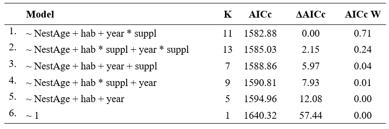

L’âge du nid et l’habitat humide présentent un effet positif sur le succès de nidification de la grande oie des neiges, au cours des trois années. Dans les deux types de milieu de reproduction, la supplémentation en eau montre un effect positive sur le SN en 2016 et 2017, alors que la supplémentation en moulée a un effet positif uniquement en 2017 (**Figure 1**; **Annexe 1**).

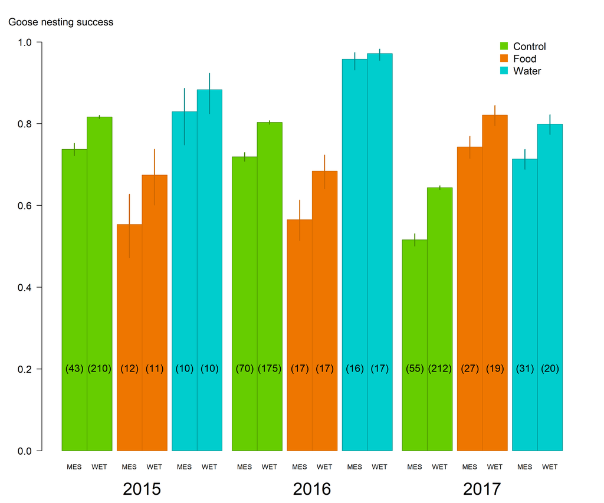

**Figure 1.** Succès de nidification de la grande oie des neiges entre 2015 et 2017 en fonction des types de traitements (*Control* pour témoin, *Food* et *Water* pour supplémentation en nourriture et en eau) et du type d’habitat (*MES* pour milieu mésique et *WET* pour milieu humide), île Bylot, Nunavut. Les nombres entre parenthèses et les barres représentent respectivement, les tailles d’échantillon et les intervalles de confiance à 95%.

## Discussion

Je souhaite articuler la discussion autour de deux axes principaux :

- Mécanismes expliquant l’effet de la supplémentation sur le succès de nidification:
  - Importance relative de l’accès à l’eau et à la nourriture au cours de la période de nidification de la grande oie des neige (besoin constant en eau / phase d’alimentation intensive entrecoupée par une phase de jeûne partiel au cours de la période de nidification)
  - Mécanismes physiologiques (meilleure condition corporelle, diminution du stress hydrique) et comportementales (modification du budget temps en faveur d’une augmentation de la quantité et de la qualité des soins parentaux, incluant la défense du nid)
- Mécanismes expliquant l’absence d’effet de la supplémentation sur le succès de nidification : effet de l’abondance des ressources naturelles qui varie selon les années car en lien avec les conditions climatiques

## Plubication des travaux

# Chapitre 3. Impact of climate variability on goose predation by Arctic fox

Collaborateurs : *Gilles Gauthier & Nicolas Lecomte*

## Mise en contexte

Le chapitre 1 met en évidence un impact du climat sur la proportion à se reproduire du renard arctique. Un des mécanismes suggérés est l’influence du climat sur le taux de consommation de la ressource (i.e., les deux proies principales, lemmings et oeufs d’oie) par le renard arctique. Mon troisième chapitre vise à identifier une relation potentielle entre les variables climatiques telles que la température de l’air, la précipitation et le vent sur le comportement de prédation du renard arctique. Dans un premier temps, je souhaite répondre à la question suivante: existe-t-il une variation du taux d’attaque du renard arctique sur les nids de la grande oie des neiges (avec adultes présents au nid) en fonction des variables climatiques telles que la température de l’air, la quantité de précipitations et la vitesse du vent ?

## Prédictions

Nous prédisons que :  
- le taux d’attaque du renard décroît abruptement à partir d’une certaine température  
- le taux d’attaque par le renard diminue avec l’augmentation des précipitations et de la vitesse du vent

À discuter…

## Méthodes

Afin de répondre à cette question, j’ai rassemblé et uniformisé des informations issues de 3 bases de données distinctes fondées sur des observations comportementales du renard arctique durant l’été à Bylot. La base de données finale regroupe 9 années de données : 1996 - 1999, 2004 - 2005 et 2015 - 2017. À partir de celle-ci, j’ai calculé un taux d’attaque par individu observé par observation. J’ai associé à chacun des taux obtenus:

- la température maximale du jour de l’observation
- la température minimale du jour de l’observation
- la quantité de précipitations du jour de l’observation
- l’indice annuel de l’abondance de lemmings
- la densité annuelle de nids d’oie

L’exploration graphique des données brutes est visible en **annexe 2**. Le taux d’attaque a été analysé à l’aide d’un modèle généralisé additif. Une fonction de lissage a été appliquée sur les variables précipitation (*rain*), température journalière maximale (*max.daily.temp*), vitesse de vent journalière maximale (*max.daily.speed*), abondance saisonnière de lemming (*lmg*) et densité saisonnière de nids d’oie (*nest.density*).

## Principaux résultats

### Sortie du modèle testé

```
##
## Family: gaussian
## Link function: identity
##
## Formula:
## AD_atq_rate ~ s(rain) + s(max.daily.temp) + s(max.daily.speed) +
##     s(lmg, k = 5) + s(nest.density, k = 5)
##
## Parametric coefficients:
##              Estimate Std. Error t value Pr(>|t|)
## (Intercept) 0.0015052  0.0001325   11.36   <2e-16 ***
## ---
## Signif. codes:  0 '***' 0.001 '**' 0.01 '*' 0.05 '.' 0.1 ' ' 1
##
## Approximate significance of smooth terms:
##                          edf Ref.df     F  p-value
## s(rain)            0.0001022      9 0.000 0.843953
## s(max.daily.temp)  1.7207664      9 1.377 0.000502 ***
## s(max.daily.speed) 0.0008458      9 0.000 0.766389
## s(lmg)             1.9126061      4 3.780 0.000128 ***
## s(nest.density)    2.1121499      4 3.981 0.000188 ***
## ---
## Signif. codes:  0 '***' 0.001 '**' 0.01 '*' 0.05 '.' 0.1 ' ' 1
##
## R-sq.(adj) =  0.102   Deviance explained = 11.6%
## -REML = -1635.8  Scale est. = 6.3516e-06  n = 362
```

### Représentation graphique du modèle

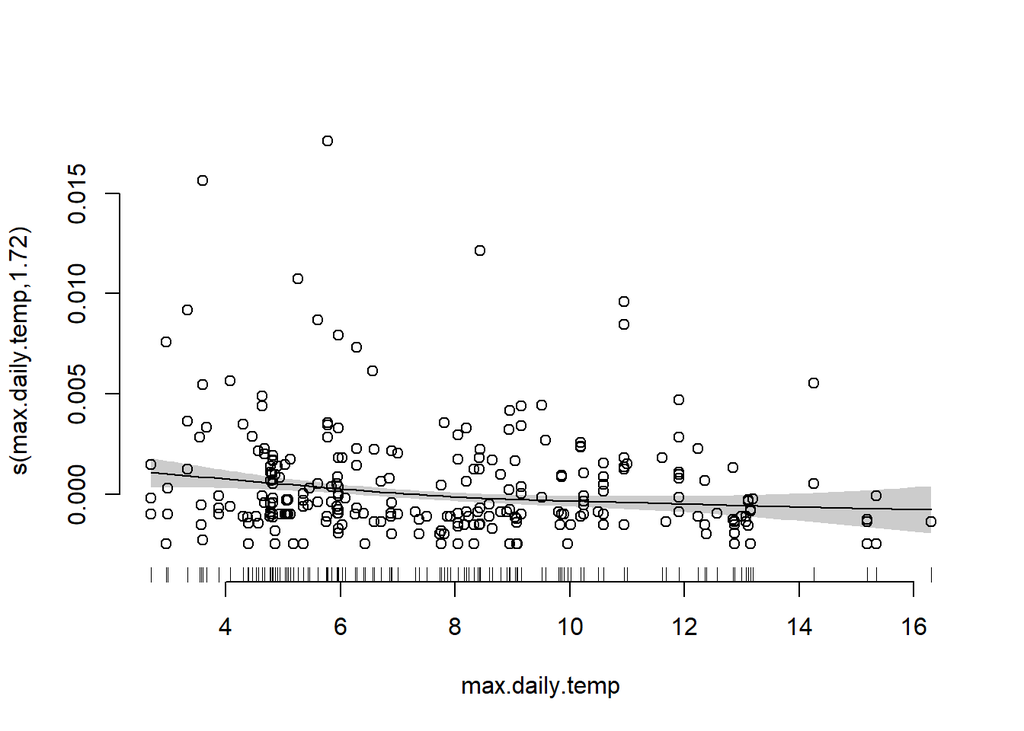

**Figure 2.** Relation entre le taux d’attaque du renard et la température journalière maximale.

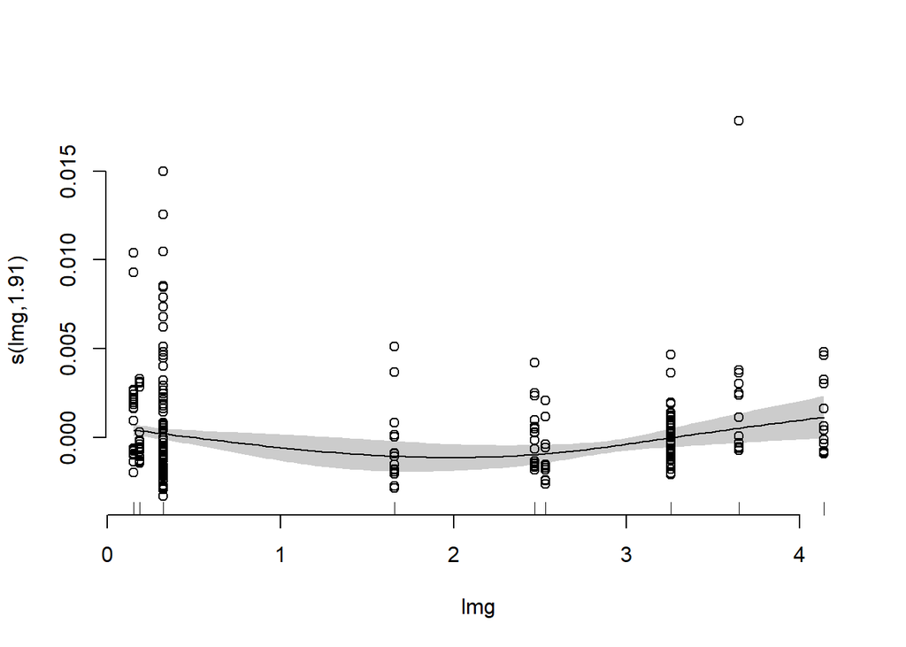

**Figure 3.** Relation entre le taux d’attaque du renard et l’abondance saisonnière de lemmings.

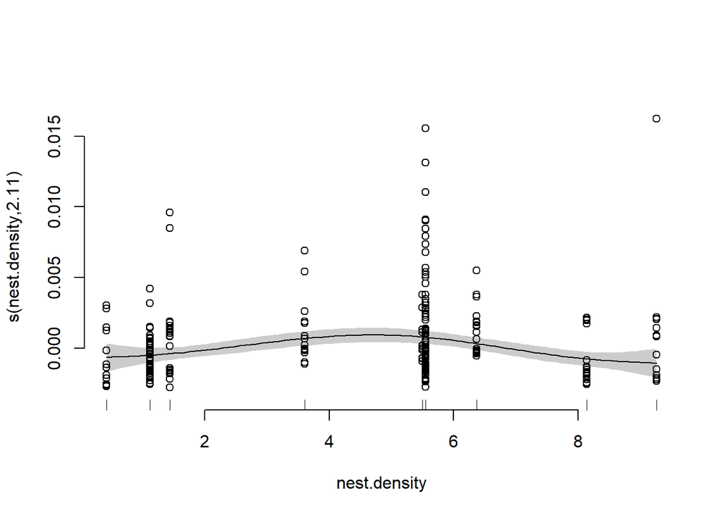

**Figure 4.** Relation entre le taux d’attaque du renard et la densité de nids d’oie saisonnière.

## Par la suite

- Utilisation de *mixture models* pour prendre en compte l’excès de 0 dans mes taux d’attaque
- Intégration de la variable année en effet aléatoire

# Chapitre 4. Picking the right cache: Cache site selection for egg predators in the Arctic

Collaborateurs : *Ambroise Lycke, Vincent Careau, Jean-François Giroux, Gilles Gauthier & Nicolas Lecomte*

## Mise en contexte

Cette étude résulte d’un projet parallèle à mon doctorat. Elle se base sur les travaux effectués par Ambroise Lycke, dans le cadre d’une initiation à la recherche supervisée par Vincent Careau en 2004. L’objectif était de voir s’il existe une sélection des sites de caches lors de la mise en réserve de nourriture par le Renard Arctique. Les données ont été récoltées au cours de l’été 2004, à l’île Bylot, Nunavut, Canada.

## Principaux résultats

Les analyses ont été effectuées à deux échelles spatiales: petite (50 cm2) et grande (5 m2). Les résultats montrent que le rrenard arctique semble sélectionner des hummocks d’environ 2 fois la taille des hummocks voisins, à petite échelle spatiale. Aucun effet des variables explicatives n’a été détecté sur la probabilité d’utilisation d’un site pour une cache par le renard à grande échelle spatiale. Pour plus de détails, voir le manuscrit.

## Publication des travaux

Suite à l’observation de ces résultats, un article a été produit et soumis à **Polar Biology** le 27 novembre 2017. Après l’acceptation du manuscrit avec révisions majeures, l’article a été resoumis le 3 avril 2018. Ces travaux ont également été présentés sous forme d’affiche à la conférence internationale du Renard Arctique en octobre 2017, à Rimouski.

# Planning prévisionnel

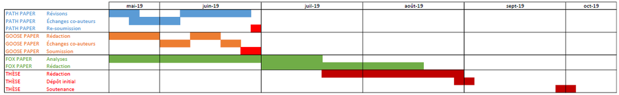

# Annexes

## **Annexe 1**

Estimés des paramètres (et erreur standard - *SE*) du meilleur modèle prédisant la probabilité de survie des nids de la grande oie des neiges de 2015 à 2017, île Bylot, Nunavut. Le modèle inclut l’âge du nid durant la visite (*NestAge*), le type d’habitat (mésique ou humide - *WET*) et une interaction entre l’année (2015, 2016, 2017 - *year*) et le type de supplémentation (contrôle, eau - *WATER* - et moulée - *FOOD*). Le niveau de référence pour le type d’habitat et la supplémentation sont, respectivement, milieu mésique et contrôle. Les tableaux **a**, **b** et **c** présentent les estimées des paramètres pour trois niveaux de référence différents de la variable année. *Lower IC* et *upper IC* indiquent les limites inférieures et supérieures des intervalles de confiance à 95%. Les estimés des paramètres significativement dont les intervalles de confiance ne chevauchent pas zéro sont représentés en gras.

**Tableau a.** Estimées des paramètres du meilleur modèle avec l’année 2015 en niveau de référence

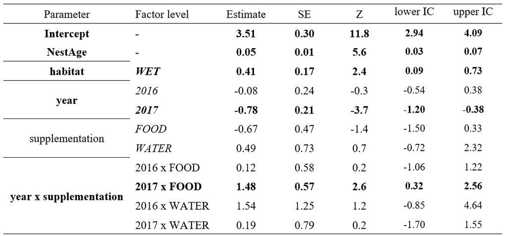

**Tableau b.** Estimées des paramètres du meilleur modèle avec l’année 2016 en niveau de référence

[figure not shown]

**Tableau c.** Estimées des paramètres du meilleur modèle avec l’année 2017 en niveau de référence

[figure not shown]

## **Annexe 2**

Exploration graphique des données analysées pour le chapitre 3.

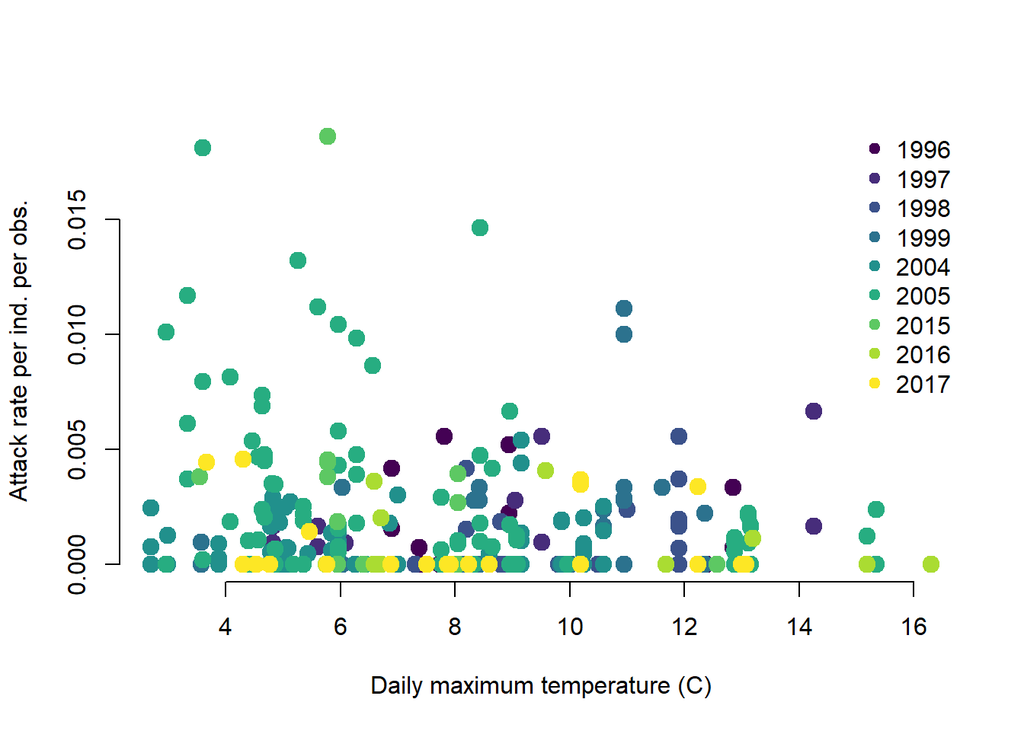

**Figure a.** Taux d’attaque par renard par observation sur des nids d’oie avec adultes présents en fonction de la température maximale du jour de l’observation.

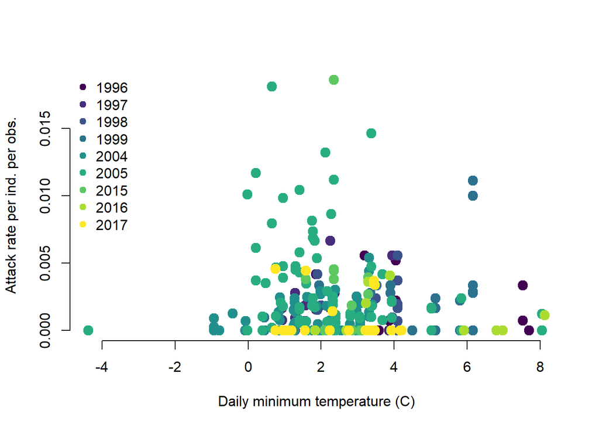

**Figure b.** Taux d’attaque par renard par observation sur des nids d’oie avec adultes présents en fonction de la température minimale du jour de l’observation.

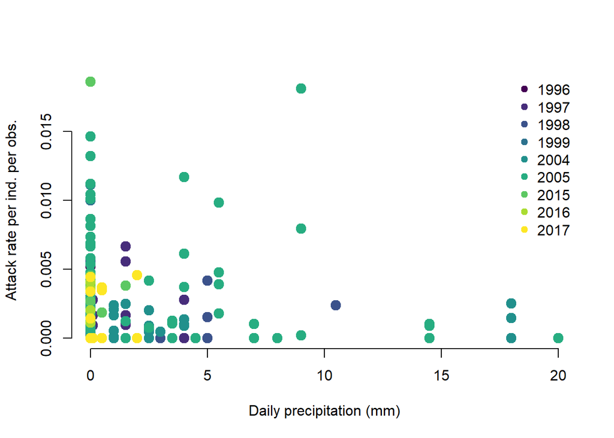

**Figure c.** Taux d’attaque par renard par observation sur des nids d’oie avec adultes présents en fonction de la précipitation du jour de l’observation.

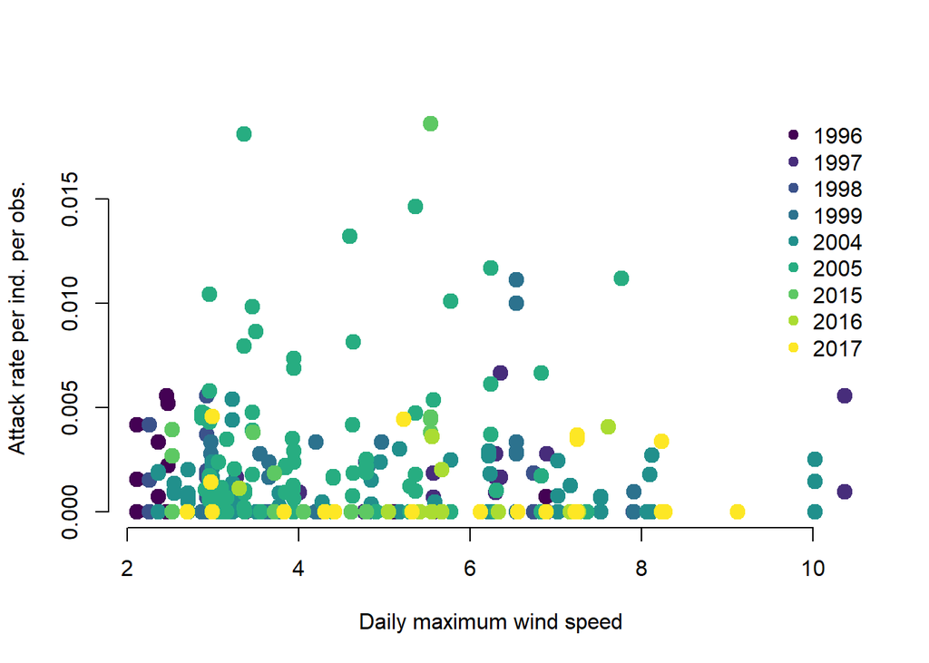

**Figure d.** Taux d’attaque par renard par observation sur des nids d’oie avec adultes présents en fonction de la vitesse maximale de vent du jour de l’observation.

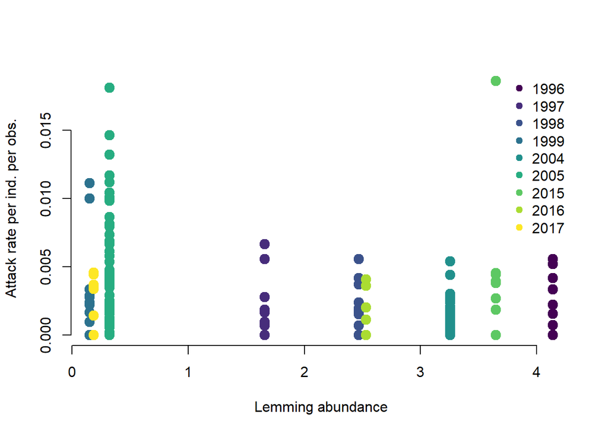

**Figure e.** Taux d’attaque par renard par observation sur des nids d’oie avec adultes présents en fonction de l’abondance saisonnière de lemming.

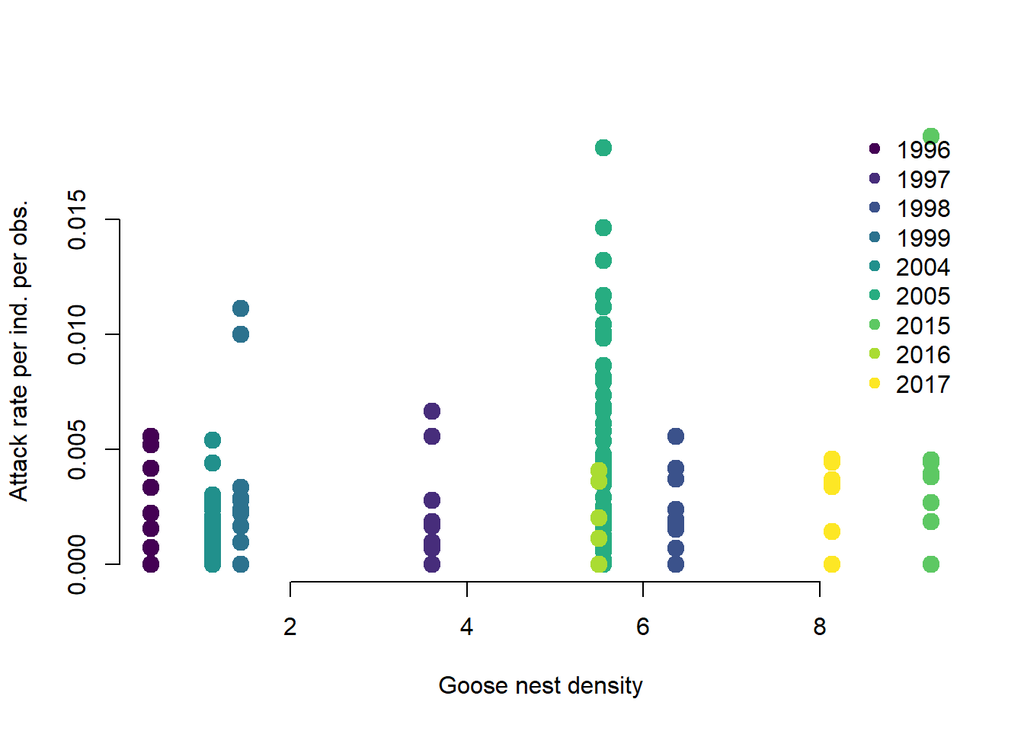

**Figure f.** Taux d’attaque par renard par observation sur des nids d’oie avec adultes présents en fonction de la densité de nids d’oie saisonnière.

[output not shown]